# Montgomery County Crash Data

Alexander Morales & Andrea Cano

March 13th, 2018

## Introduction

This document visualizes crash data in the Montgomery County. It provides graphical evidence to answer multiple questions about safety or just simple curiosities when it comes to crashes.

```r
dat=read.csv(file = "Crash_report.csv")
```

## Where Data got collected and why ?

This document explores the information provided on the crash reports in Montgomery County. This information is focused on the traffic collisions on local roadways collected by the Automated Crash Reporting System (ACRS) from the Maryland State Police.

```r
library(ggmap)
```

[figure not shown]

```r
coordinate = gsub("[()]","",dat$Location)
coordinate = unique(sort(coordinate))
coo = as.data.frame(table(coordinate))
maC = names(which.max(table(coordinate)))
map = get_map(maC, maptype = "satellite",zoom = 16)
p = ggmap(map)
p
```

## Initial Data Exploration

```r
summary(dat)
str(dat)
```

While first encountering this data we noticed multiple missing values and were curious as to why that was and if it was a large part of the data. Once those were taken care of, we started noticing interesting trends of the crashes within this route. *How does the weather effect crashing?* *Is there a specific time of year where the crashes are more prominent?* *How about a specific time of day? (Rush hour?)* *Is substance abuse a factor?*

## Data Cleaning and Preprocessing

*Examples:*

```r
substance=dat$Driver.Substance.Abuse
substance = gsub("N/A","UNKNOWN", substance)

dat$dtime = strptime(as.character(dat$Crash.Date.Time),"%m/%d/%Y %I:%M:%S %p", tz ="EST")
par(mar=c(4,5,2,1))
hours = dat$dtime$hour + 1
tab = as.data.frame(table(hours))
```

*Explanation:*

Throughout the exploration, there were multiple encounters with missing or incomplete data. to work around these issues, and prevent from data getting lost, we ‘imputed’ the data to Unknown values rather than NA. As well as, preprocessing data such as with the time of crashes to where it can be separated and used to answer the proposed questions. Due to a vast amount of unknowns, and inadequate information in the data acquired, we individually cleaned only data that sparked our curiousity to know about Montgomery county.

## Data exploration and Visualization

### Does Weather Influence the Amount of Crashes?

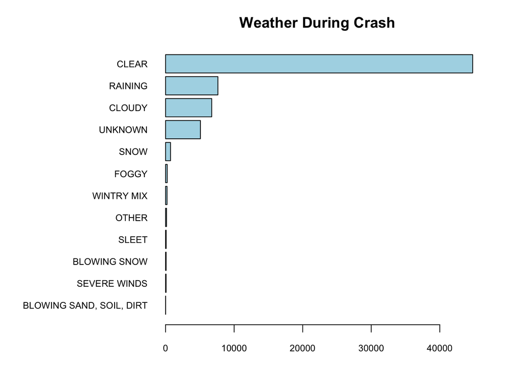

```r
par(mar = c(3,11,3,3))
weather = dat$Weather
weather = gsub("N/A","UNKNOWN", weather)
barplot(sort(table(weather)),horiz = TRUE, las=1,col = "lightblue", main = "Weather During Crash", cex.names = .75, cex.axis = .75)
```

*Analysis:*

As seen in the graph, extreme weather does not have as much of an influence as expected. Most crashes occur when the weather is clear meaning that weather is not a likely cause for these crashes. Although, the amount of Unknowns in the data could change our assumption on if weather is an issue.

### Is there a Month when Crashes are more Prominent?

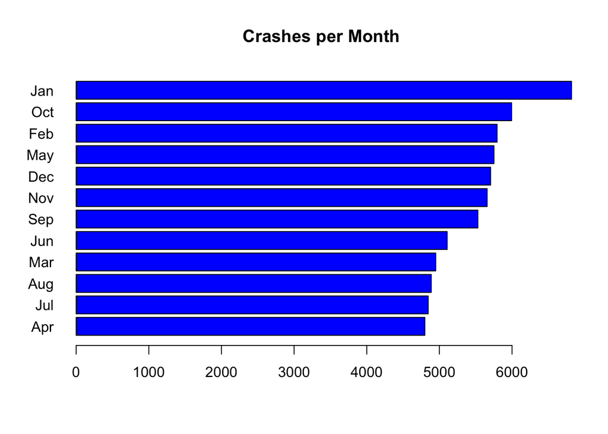

```r
#checking Months
dat$dtime = strptime(as.character(dat$Crash.Date.Time),"%m/%d/%Y %I:%M:%S %p", tz ="EST")
months = dat$dtime$mon +1
months = month.abb[months]
barplot(sort(table(months)), horiz = TRUE, las = 1, main = "Crashes per Month", col = "blue")
```

*Analysis:*

### Is Substance Abuse a Factor?

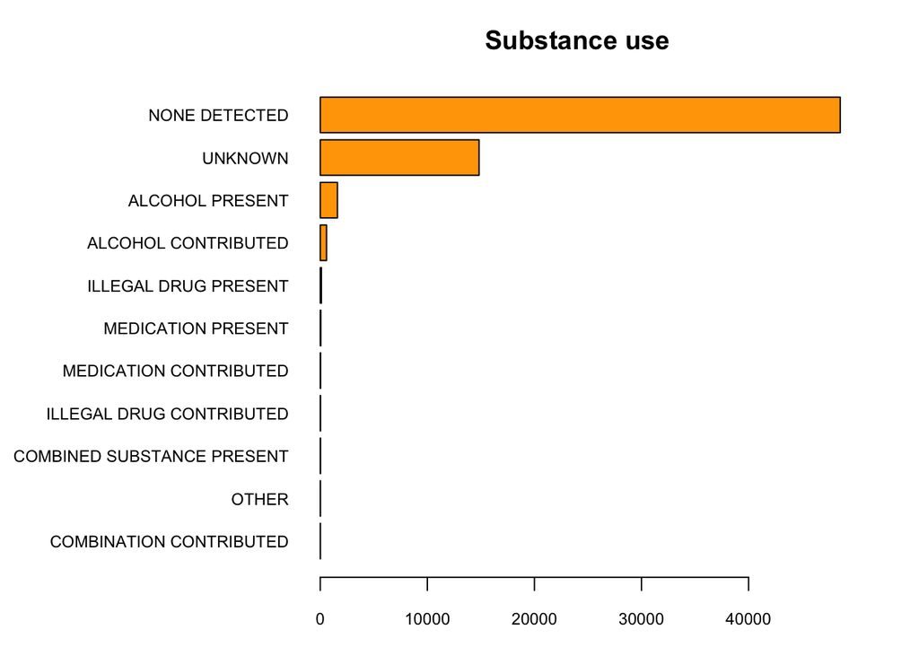

```r
substance=dat$Driver.Substance.Abuse
substance = gsub("N/A","UNKNOWN", substance)
par(mar=c(3,12,3,3))
barplot(sort(table(substance)),horiz = TRUE,las=1,col = "orange", main = "Substance use",cex.names = .75,cex.axis = .75)
```

*Analysis:*

The data collected from Montgomery county had some “N/A” values for substance use.However; we were curious to see how many people were under the influence while conducting the vehicle in the county. We were astonished once we imputed all the “N/A” values in the data to “UNKNOWN” that majority of the accidents the driver was not under the influence. Also, that there was vast amount of “UNKNOWN”, which can change the outcome of this analysis.

### Is Speeding a Factor?

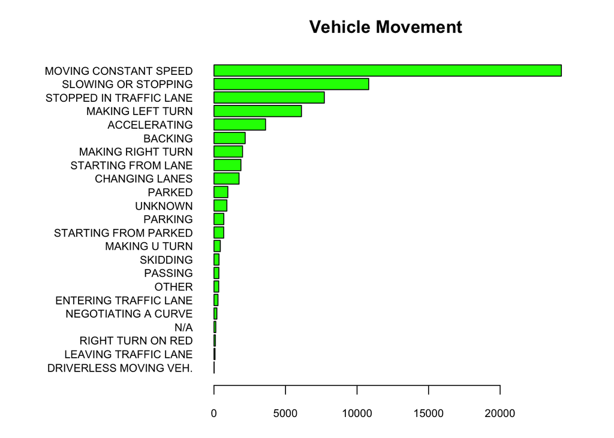

```r
par(mar=c(3,12,3,3))
barplot(sort(table(dat$Vehicle.Movement)),horiz = TRUE,las=1,col = "green", main = "Vehicle Movement",cex.names = .75,cex.axis = .75)
```

*Analysis:*

### Are the Crashes due to Traffic Control?

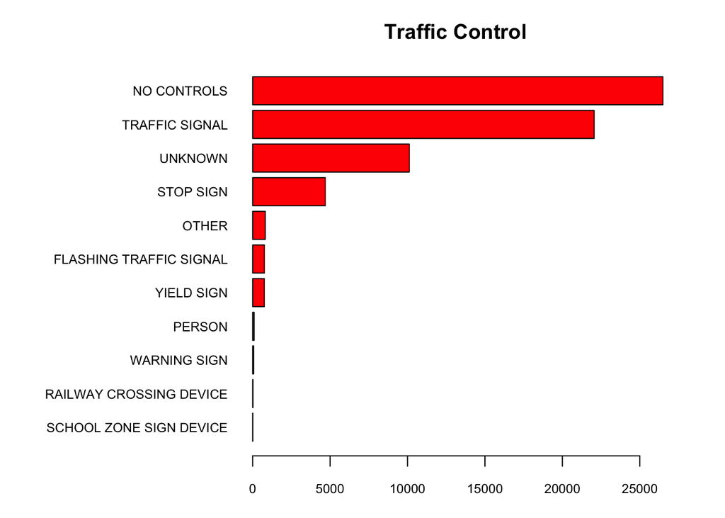

```r
t.control=dat$Traffic.Control
t.control = gsub("N/A","UNKNOWN",t.control)
par(mar=c(3,12,3,3))
barplot(sort(table(t.control)),horiz = TRUE,las=1,col = "red", main = "Traffic Control",cex.names = .75,cex.axis = .75)
```

*Analysis:*

### Is Rush Hour a Factor?

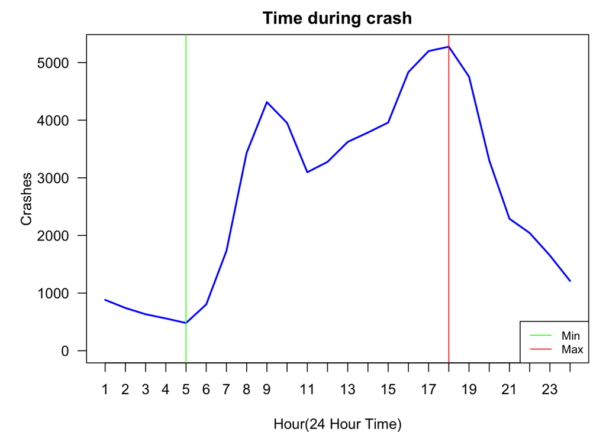

```r
dat$dtime = strptime(as.character(dat$Crash.Date.Time),"%m/%d/%Y %I:%M:%S %p", tz ="EST")
par(mar=c(4,5,2,1))
hours = dat$dtime$hour + 1
tab = as.data.frame(table(hours))

plot(table(hours), las = 1, main = "Time during crash", col = "blue",type = "l",xlab = "Hour(24 Hour Time)", ylab = "Crashes")
dtab = as.data.frame(table(hours))
maH = names(which.max(table(hours)))
max.line = as.numeric(maH)
abline(v = max.line, col = "red")
miH = names(which.min(table(hours)))
min.line = as.numeric(miH)
abline(v = min.line, col = "green")

legend("bottomright", legend=c("Min", "Max"),
       col=c("green", "red"), lty=1:1, cex=0.8)
```

*Analysis:*

According to this line plot, ‘rush hour’ is between 5-18 in 24-hour time (5am to 6pm). At this time most crashes will occur at 18(6pm) and the least likely time for a crash to occur is at 5(5am). So driving in the evening has a higher probability to have an accident.